# Where Shootings Are Higher, People of Color Bear the Brunt

Jacob Moore

#### **Data Source**

[Webpage](https://catalog.data.gov/dataset/nypd-shooting-incident-data-historic/resource/c564b578-fd8a-4005-8365-34150d306cc4), [CSV](https://data.cityofnewyork.us/api/views/833y-fsy8/rows.csv?accessType=DOWNLOAD)

### **Introduction**

The objective of this study is to demonstrate the relationship between the number of shooting incidents in New York City and the proportion of shooting victims involved in those incidents who are members of racial minorities. This study will first determine how racial breakdowns of New York Police Department shooting incident data compare between the five boroughs of New York City: the Bronx, Brooklyn, Manhattan, Queens, and Staten Island. Second, this study will examine the data’s implication that increases in the number of shooting incidents coincide with a decrease in the proportion of shooting victims identified as White. Therefore, a higher proportion of shooting victims are people of color. This study then shows that this relationship continues to hold when the data is sorted by precinct, rather than borough.

### **NYC Overall Data Summary**

This data set provides a record of shooting incidents occurring in New York City between 2006 and 2020. There were 25596 shooting incidents total recorded by the NYPD in this data set.

81.13% of victims were Black and 24.33% were Hispanic, with 2.58% being White and non-Hispanic. 1.67% of shooting victims belonged to other races or were listed as being of unknown race. Note that percentages sum to more than 100 because some victims are listed as both Black and Hispanic or White and Hispanic.

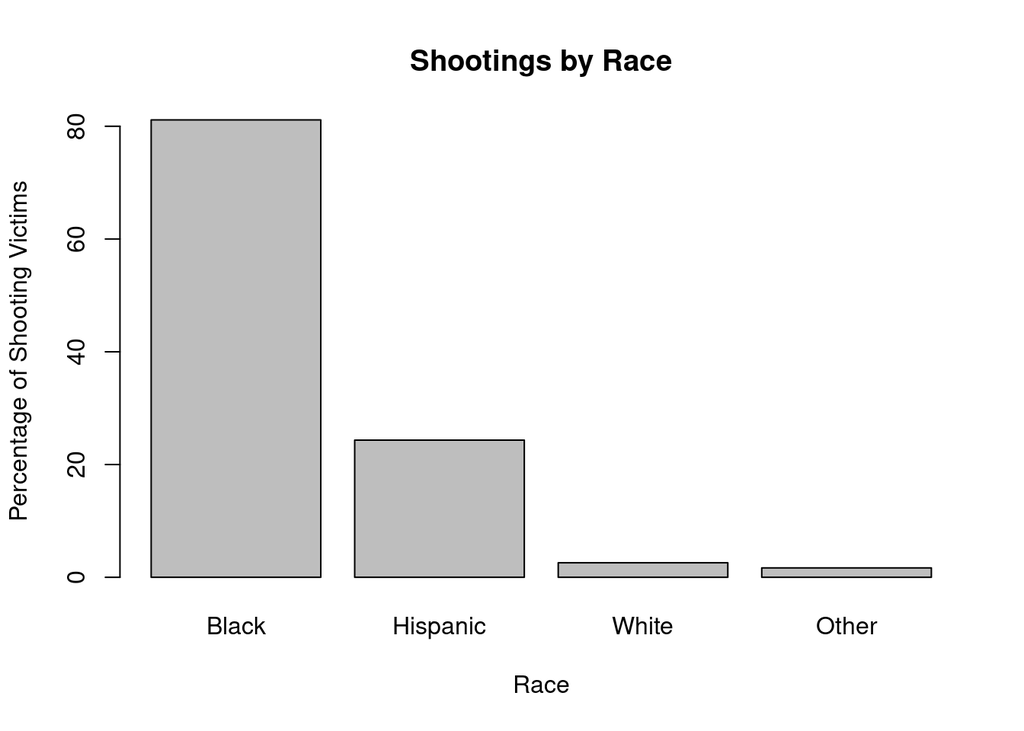

### **Boroughs Data Summaries**

#### **Bronx Data Summary**

There were 7402 shooting incidents recorded by the NYPD in this data set in the Bronx, which is 28.92% of the total shooting incidents in New York City.

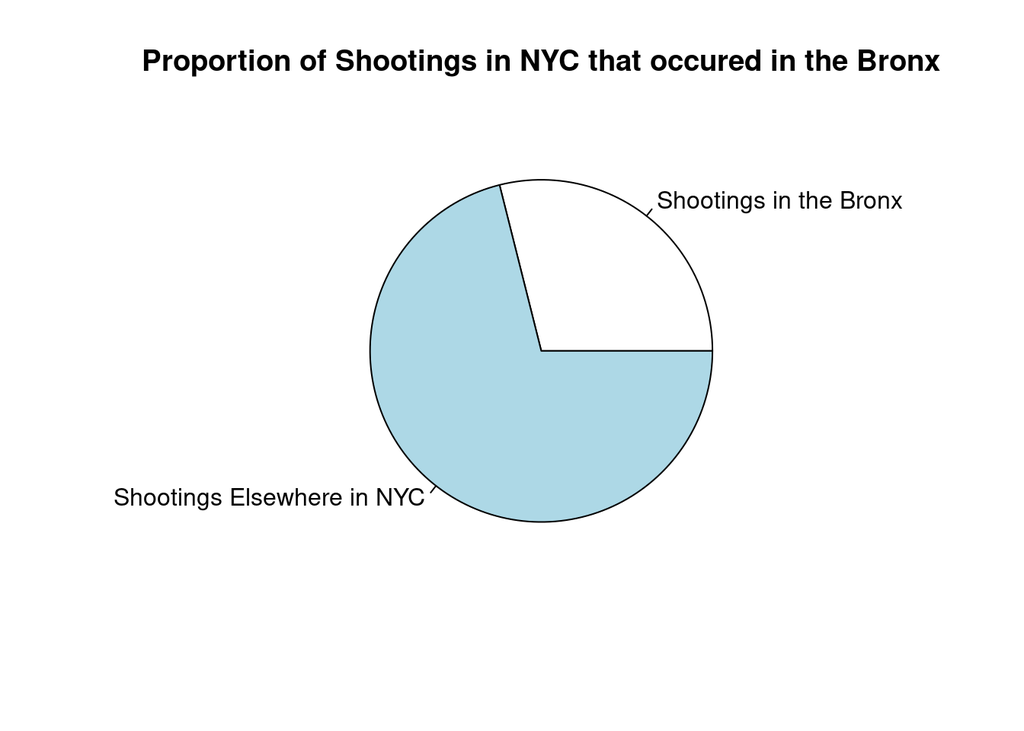

73.9% of victims were Black and 39.58% were Hispanic, with 1.63% being White and non-Hispanic. 1.11% of shooting victims belonged to other races or were listed as being of unknown race. Note that percentages sum to more than 100 because some victims are listed as both Black and Hispanic or White and Hispanic.

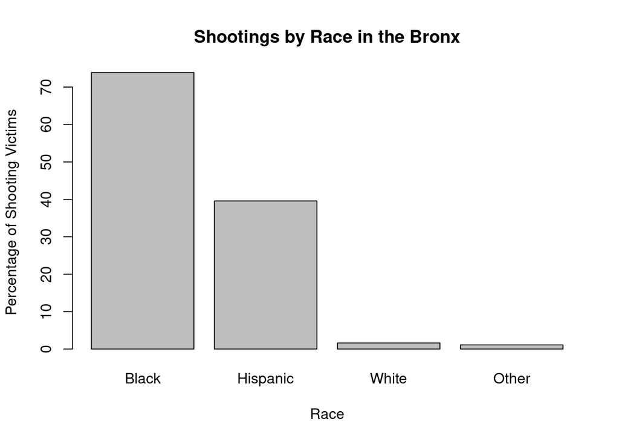

#### **Brooklyn Data Summary**

There were 10365 shooting incidents recorded by the NYPD in this data set in Brooklyn, which is 40.49% of the total shooting incidents in New York City.

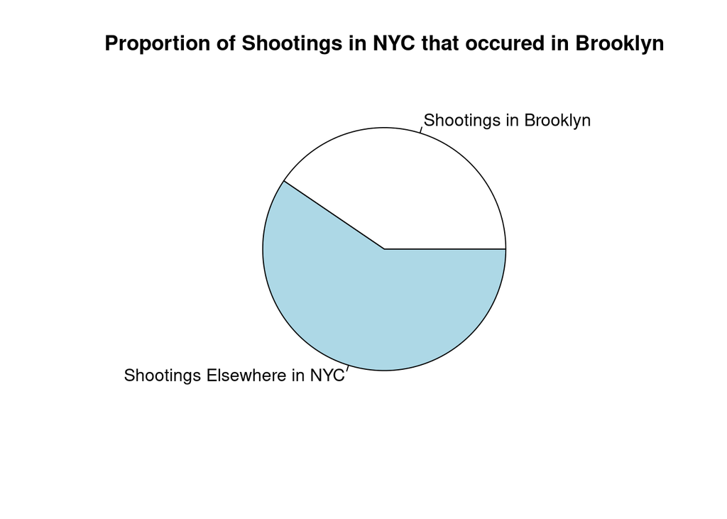

88.46% of victims were Black and 12.92% were Hispanic, with 2.32% being White and non-Hispanic. 1.41% of shooting victims belonged to other races or were listed as being of unknown race. Note that percentages sum to more than 100 because some victims are listed as both Black and Hispanic or White and Hispanic.

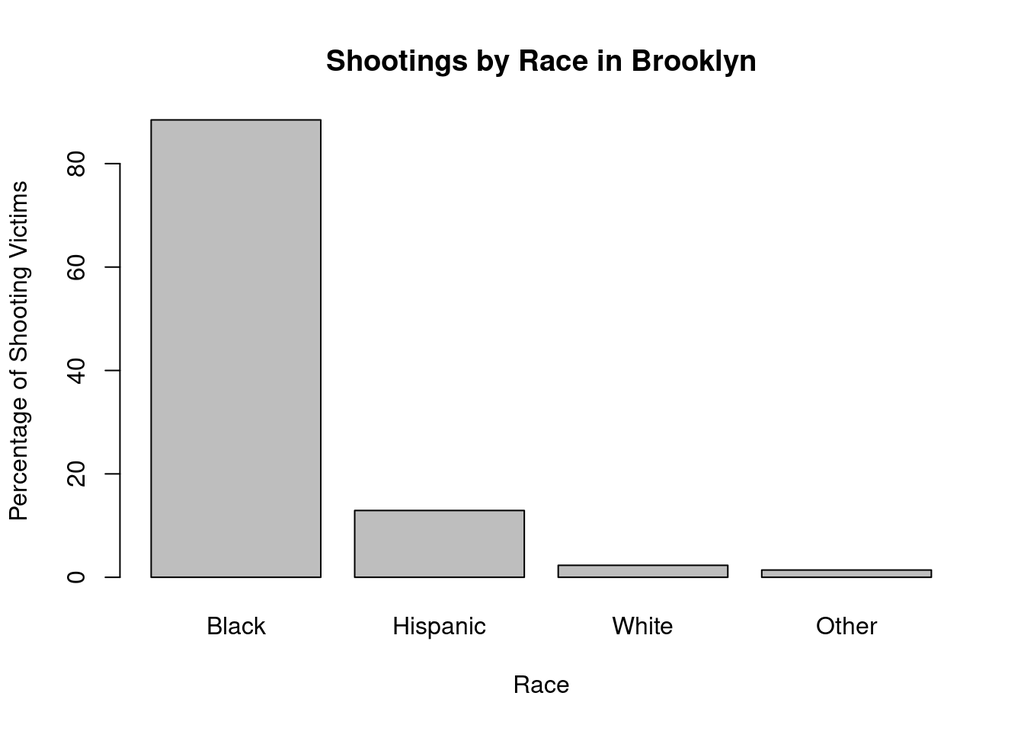

#### **Manhattan Data Summary**

There were 3265 shooting incidents recorded by the NYPD in this data set in Manhattan, which is 12.76% of the total shooting incidents in New York City.

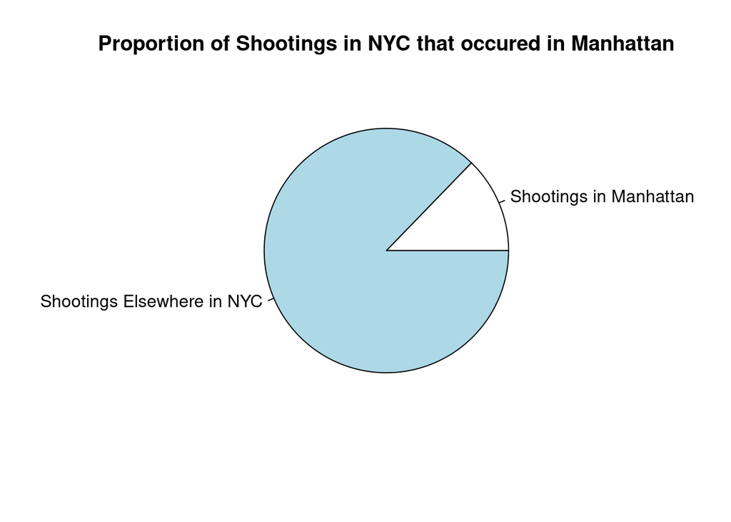

77.92% of victims were Black and 32.89% were Hispanic, with 2.08% being White and non-Hispanic. 1.38% of shooting victims belonged to other races or were listed as being of unknown race. Note that percentages sum to more than 100 because some victims are listed as both Black and Hispanic or White and Hispanic.

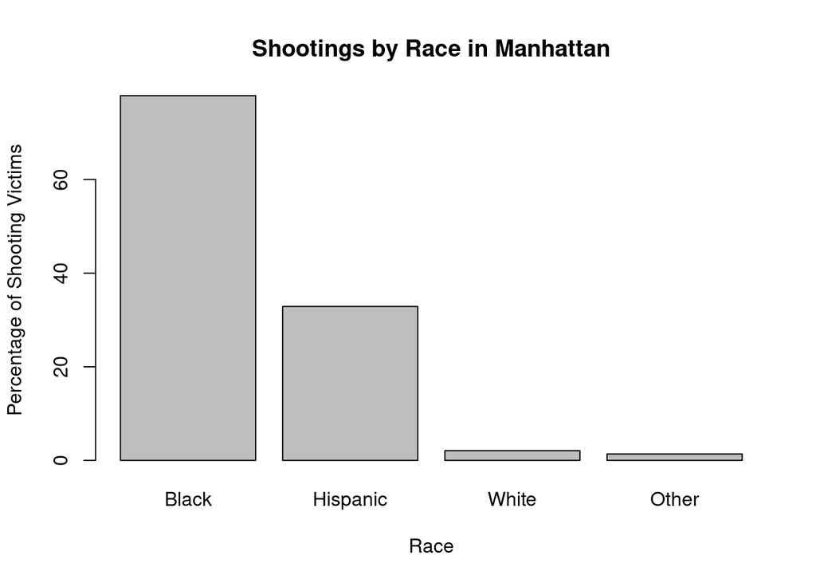

#### **Queens Data Summary**

There were 3828 shooting incidents recorded by the NYPD in this data set in the Queens, which is 14.96% of the total shooting incidents in New York City.

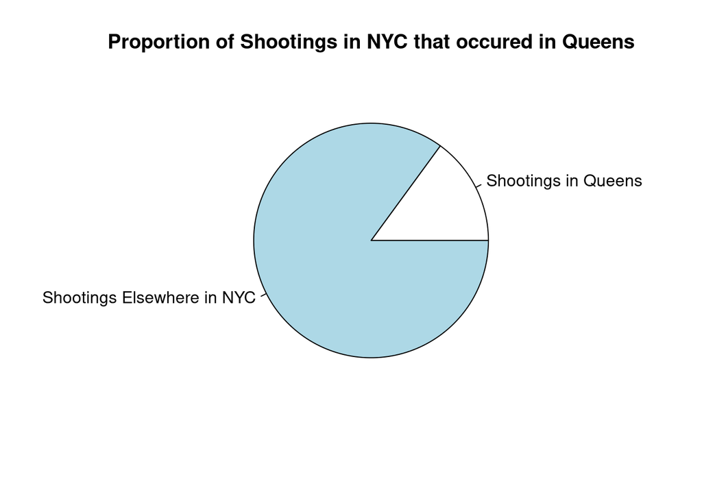

79.08% of victims were Black and 19.51% were Hispanic, with 3.97% being White and non-Hispanic. 3.92% of shooting victims belonged to other races or were listed as being of unknown race. Note that percentages sum to more than 100 because some victims are listed as both Black and Hispanic or White and Hispanic.

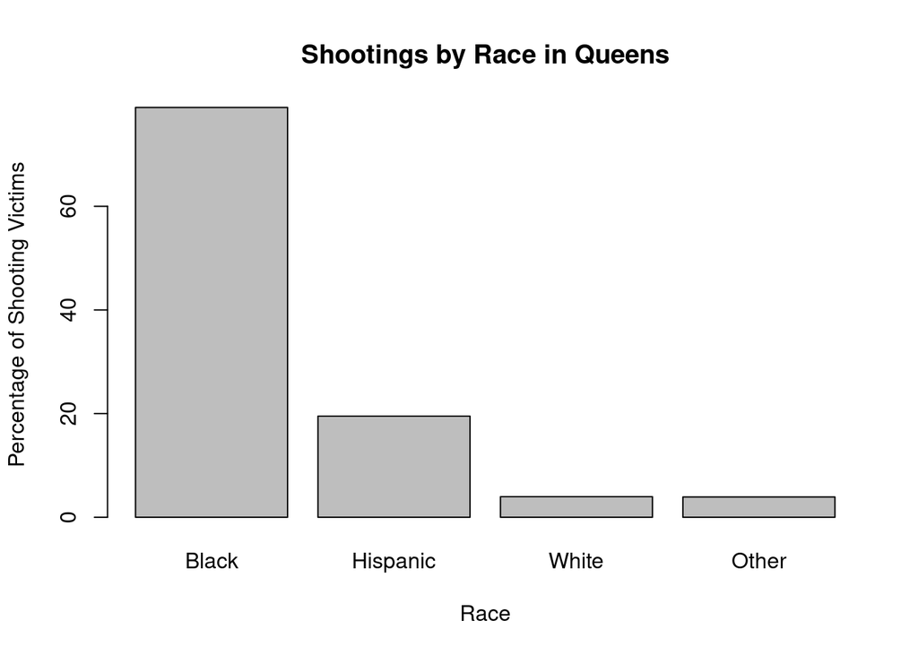

#### **Staten Island Data Summary**

There were 736 shooting incidents recorded by the NYPD in this data set in Staten Island, which is 2.88% of the total shooting incidents in New York City.

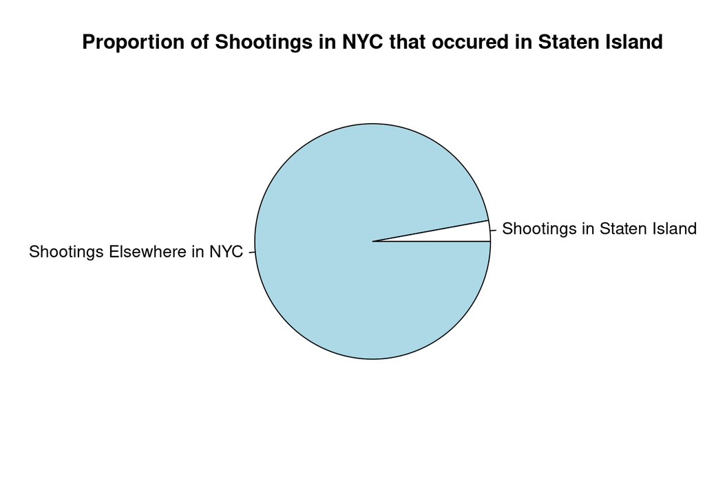

75.54% of victims were Black and 18.61% were Hispanic, with 10.73% being White and non-Hispanic. 0.68% of shooting victims belonged to other races or were listed as being of unknown race. Note that percentages sum to more than 100 because some victims are listed as both Black and Hispanic or White and Hispanic.

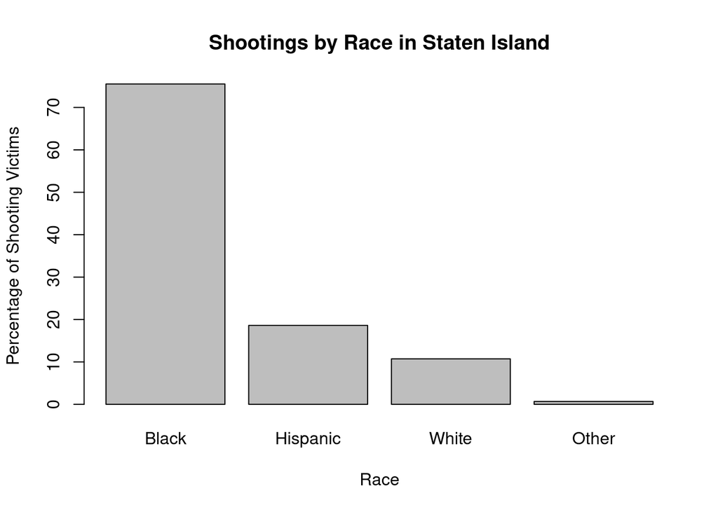

### **Analysis**

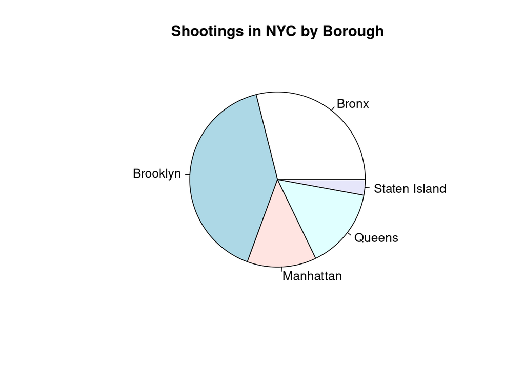

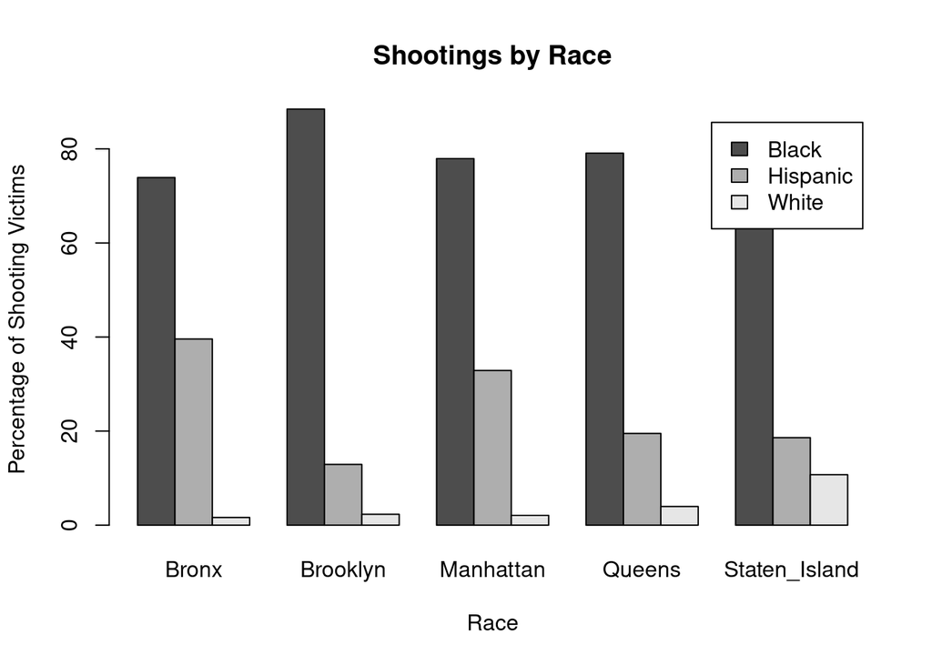

As you can see from the pie chart above, the number of shooting incidents vary significantly from borough to borough. One interesting correlation that emerges is that boroughs with fewer shooting incidents seem to have a higher proportion of white victims. Or, alternatively, boroughs with higher numbers of shooting incidents have higher proportions of shooting victims who are members of racial minorities. Thus, when shooting incidents go up, it is predominantly minority communities who are most harmed.

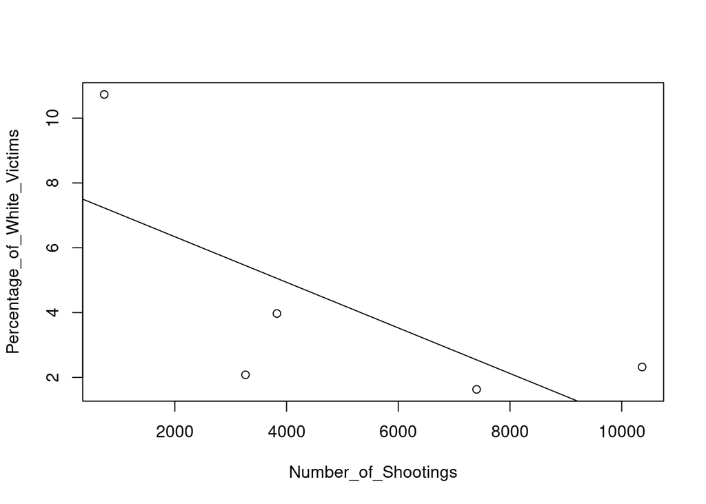

This graph plots each borough by number of shooting incidents and proportion of shooting victims who were identified as White with a line of best fit showing a negative correlation. As this plot suggests, there is a real relationship here. However, with this few data points, no strong conclusion can be established with any real certainty.

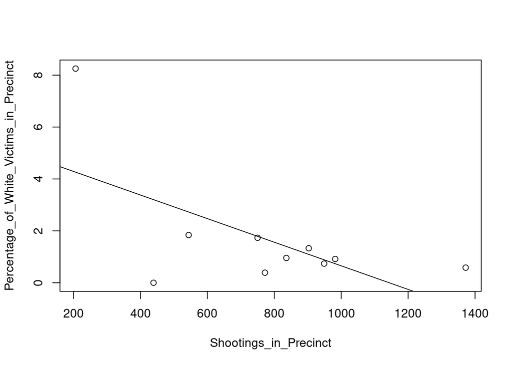

This graph shows each precinct plotted by number of shootings and percentage of shooting victims who were identified as White with a line of best fit showing a negative correlation. So, the suspected relationship holds. Where there are fewer shootings, a higher proportion of shooting victims are white. Therefore, where there are more shootings, a higher proportion of shooting victims are people of color.

#### **Biases, Confounders, and Suggestions for Further Research**

Clearly, a larger sample size is necessary to determine if the relationship between number of shootings and racial make up of shooting victims holds at a larger scale. Data from other cities would be extremely useful here.

Further research is also necessary to determine what effects if any, may be confounding this data. Of particular concern would be the racial make up of the general population of each borough. While it currently appears to be the case that boroughs with fewer incidents have a greater proportion of White victims, it may only be the case that those boroughs have a higher proportion of White people in the general population. It may also be that boroughs with fewer shooting incidents have smaller populations which would suggest that it is smaller populations which are correlated with the higher proportion of White victims, not the smaller number of shooting incidents, per se.